# EXPLORATORY DATA ANALYSIS CSC 3220 - Real Estate Data

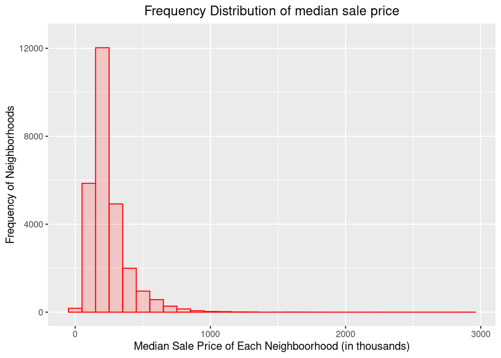

```r
print(
    ggplot(new_df, aes_string(x=new_df$median_sale_price))
    + geom_histogram(
      colour="red", fill="firebrick1", position="identity", bins=30, alpha=0.2
    )
    + ggtitle(paste("Frequency Distribution of median sale price", sep=""))
    + theme(plot.title=element_text(hjust = 0.5))
    + xlab("Median Sale Price of Each Neighboorhood (in thousands)")
    + ylab("Frequency of Neighborhoods")
    + ylim(0, 12500))
```

We can create a bin plot to demonstrate that home sale prices tend to aggregate below a million, between 100 thousand to 300 thousand. We have fitted a best fit line to show that there is a positive increase in median sales price over time, however, with a r-squared value of 0.125, only 12.5% of this increase can be explained by time. This is understandable, since the value of a home includes many factors such as: location, land, size, time built, etc. We can see that both the townhouse and multi-family units have extreme outliers in the median sales price.

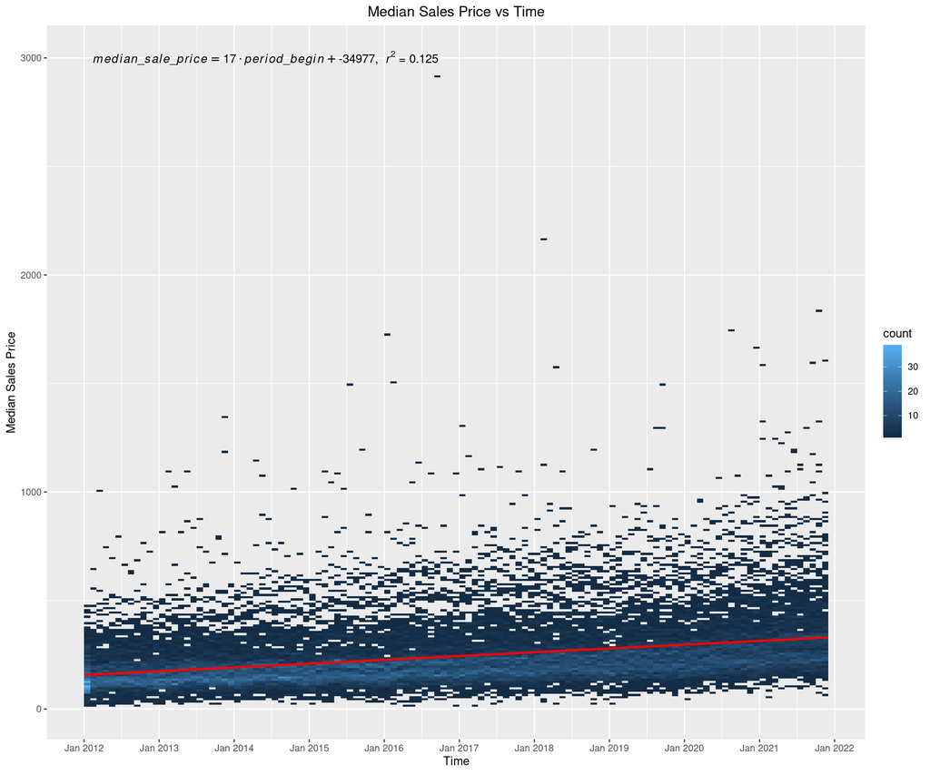

```r
lm_eqn <- function(df){
    m <- lm(median_sale_price ~ as.yearmon(period_begin), df);
    eq <- substitute(italic(median_sale_price) == b %.% italic(period_begin) + a*","~~italic(r)^2~"="~r2,
         list(a = format(unname(coef(m)[1]), digits = 2),
              b = format(unname(coef(m)[2]), digits = 2),
             r2 = format(summary(m)$r.squared, digits = 3)))
    as.character(as.expression(eq));
}

ggplot(state_market.df, aes(x = as.yearmon(period_begin), y = median_sale_price)) +
  geom_bin_2d(binwidth = c(1/12, 10)) +
  xlab("Time") +
  ylab("Median Sales Price") +
  ggtitle("Median Sales Price vs Time") +
  theme(plot.title = element_text(hjust = 0.5)) +
  scale_x_yearmon(n = 10) +
  geom_smooth(method = "lm", se = FALSE, color = "red") +
  annotate("text", x = as.numeric(as.yearmon("2014-06-01")), y = 3000, parse = TRUE, label = lm_eqn(state_market.df))
```

#### Both townhouse and multi-family have extreme outliers in the median sales price.

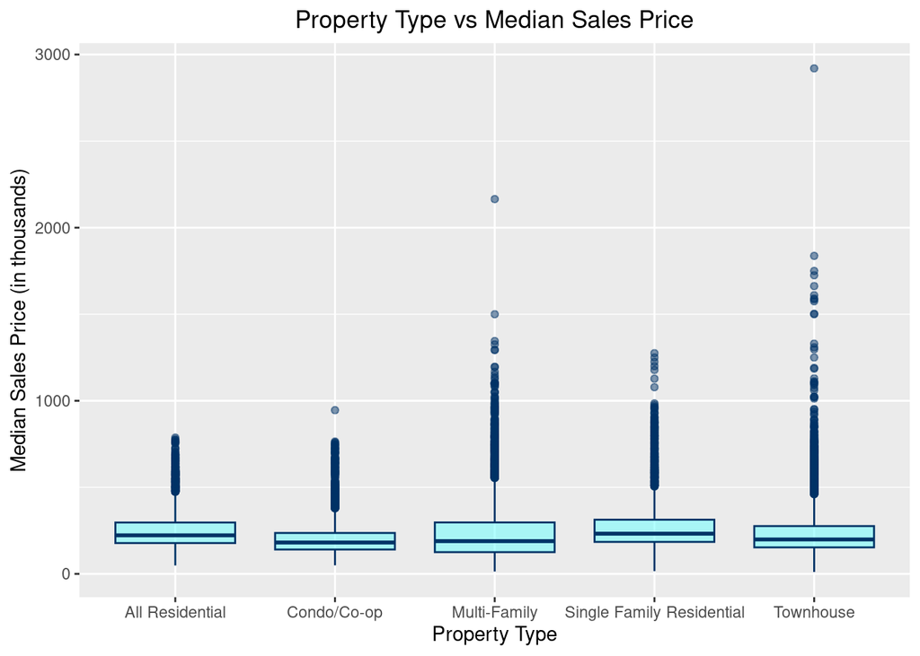

```
## For our outlier tests, we will test if anything is above the 99th quantile. We can see
## that for the outliers for multi-family housing the state Hawaii has the most outliers. This
## gives us a good explanation in the reason for the outliers, since Hawaii is a small state
## in the middle of the Pacific serverely limiting the supply of land.
```

```
##
## California   Columbia     Hawaii New Mexico
##         11         11         30          3
```

```
## The same thing is repeated with townhouses, but Connecticut has almost as many as Hawaii
## now. There is a possibility that the reasoning behind this is the same as Hawaii with the
## limited supply of land, but it also could be that mostly everywhere in Connecticut is close
## to a town or city that sports many amenities.
```

```
##
##    Columbia Connecticut      Hawaii       Maine
##           9          19          20           2
```

```r
ggplot(state_market.df, aes(x = property_type, y = median_sale_price)) +
  geom_boxplot(colour="#003366", fill="#66FFFF", alpha=1/2) +
  xlab("Property Type") +
  ylab("Median Sales Price (in thousands)") +
  ggtitle("Property Type vs Median Sales Price") +
  theme(plot.title = element_text(hjust = 0.5))
```